# Seaborn

# 多图网格

当我们将row和col变量用于线形图中的各种可视化方面时，我们已经看到了某些类型的多图网格。 但是， seaborn 提供了三组用于不同用途的预定义网格。

jointplot()和JointGrid()启用，将创建三个轴域/图作为一个图形。 主轴域称为联合图，其他两个称为边缘轴域。 边缘轴域之一在联合图的顶部，第二边缘轴域在联合图的右侧。 在联合图上绘制了两个变量之间的关系，并且在每个边缘轴域上绘制了这两个变量中的每一个的单变量分布。 这些函数具有各种参数，可以灵活地在这三个轴域的每一个上选择和类型的图形。

pairplot()和PairGrid()可以成对出现，每个成对包含两个变量。 我们只需传递宽格式数据集，并使用一条语句，就可以得到以行和列的网格形式显示所有数值变量之间成对关系的图形。 同样，这里有许多选择不同类型图形的选项。

jointplot()和JointGrid()以及pairplot()和PairGrid()之间的区别在于，可以灵活地选择各种参数和每种参数提供的图形类型。jointplot()和pairplot()灵活性较差，但易于使用并可以快速绘制。JointGrid()和PairGrid()提供更多的灵活性，有许多参数可供选择。

FacetGrid()是多图网格的第三类。 用于hue，style，size，row和col变量的组合的多维分析。 我们已经在关系图和类别图的上下文中看到了这些。 他们在内部使用FacetGrid()； 在这里，我们将直接访问它。

## jointplot和jointGrid

### jointplot

jointplot只能设置五种类型的图形

`kind`参数:默认scatter,其他四种为：kde，hex，reg，resid，这个是联合轴域的类型

`marginal_kws`参数:设置边缘轴域的参数，默认边缘轴域绘制直方图和kde曲线。

```
bins=15是要绘制的直方图的仓数； 默认情况下，将绘制直方图。
fit=norm指定为给定数据拟合normal分布曲线。
rug=True绘制给定数据的地毯图。
color='darkblue'是用于两个边缘轴域的所有元素的颜色。
space=0.1指定，联合图和边缘轴域之间的间距。 0表示它们紧密连接，彼此之间没有任何缝隙。
color='g'指定联合绘图对象的颜色。如果该参数中没有设置颜色，则颜色跟联合轴域保持一致。
默认情况下，KDE 曲线将适合数据。 如果我们不想绘制它，我们应该将其设置为false。 在这种情况下，我们将同时具有 KDE 曲线和normal分布曲线。
```

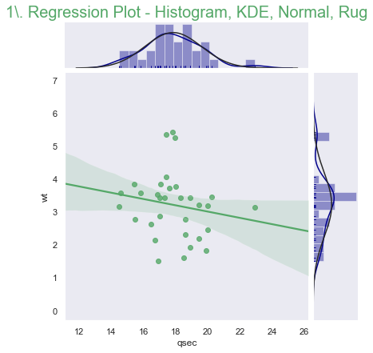

```python
#绘制回归图：
g1 = sns.jointplot(x='qsec', y='wt', data=data, kind='reg', marginal_kws=dict(bins=15, fit=norm, rug=True, color='darkblue'), space=0.1, color='g')
g1.ax_marg_x.set_title('1\. Regression Plot - Histogram, KDE, Normal, Rug', size=20, color='g')
```

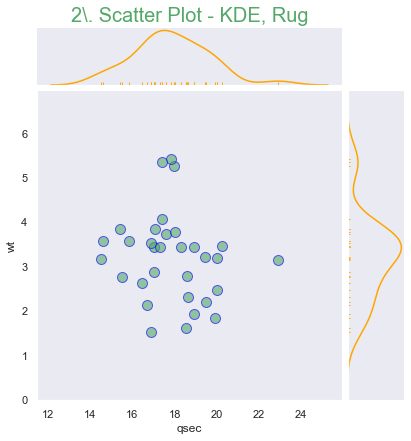

```python
#绘制散点图：
g2 = sns.jointplot(x='qsec', y='wt', data=data,
                   s=100, marginal_kws=dict(kde=True, rug=True,
                   hist=False, color='orange'), space=0.1,
                   color='g', edgecolor="blue", alpha=0.6)
g2.ax_marg_x.set_title('2\. Scatter Plot - KDE, Rug', size=20,
                        color='g')
```

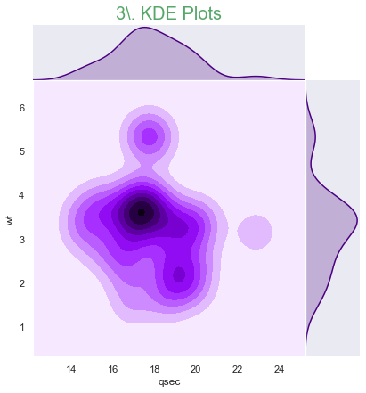

```python
#绘制 KDE 图：
g3 = sns.jointplot(x='qsec', y='wt', data=data,
                   kind='kde', space=0, color='indigo')
g3.ax_marg_x.set_title('3\. KDE Plots', size=20, color='g');
```

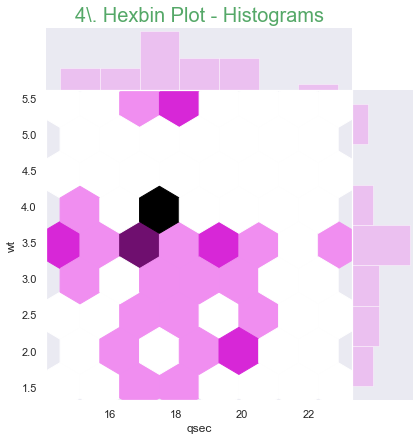

```python
#绘制六角箱图：
g4 = sns.jointplot(x='qsec', y='wt', data=data,
                   kind='hex', space=0, color='violet');
g4.ax_marg_x.set_title('4\. Hexbin Plot - Histograms', size=20,                        color='g');
```

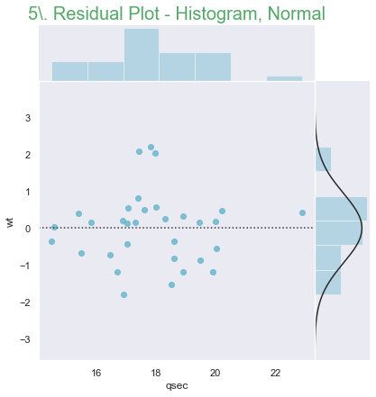

```python
#绘制残差图：
g5 = sns.jointplot(x='qsec', y='wt', data=data,
                   kind='resid', space=0, color='c')
g5.ax_marg_x.set_title('5\. Residual Plot - Histogram, Normal',
                        size=20, color='g');
```

### JointGrid

1. 第一种，联合绘图和边缘绘图一起设置
   - 首先声明网格绘图，确定数据

     ```
     g1 = sns.JointGrid(x='Coffee', y='Cookies', data=snacks_sales, space=0.1, height=6, ratio=2)#通过jointGrid设置x和y轴数据
     x和y确定数据
     space=0.1是联合图和边缘图之间的差距量。
     height=6是绘图的高度，以英寸为单位。
     ratio=2是联合绘图高度与边缘绘图高度的比率。
     ```

   - 确定联合和边缘绘图 g1 = g1.plot(sns.regplot, sns.kdeplot)#声明联合和边缘的绘图，可以是任意类型。
   - 然后之后逐步设置参数
2. 第二种 分开绘制联合和边缘，但是边缘图不分开，保持一致
   - 首先同样是声明网格绘图，确定数据 g2 = sns.JointGrid(x='Pies', y='Smoothies', data=snacks_sales, space=0, ratio=2)#确定数据，绘制网格
   - 分别绘制边缘图和联合图

     ```
     `g2.plot_joint()`绘制联合图，g2=g2.plot_joint(sns.regplot, color="g", order=3, ci=68 )刷新g2，添加联合图
     `g2.plot_marginals()`绘制边缘图，g2 = g2.plot_marginals(sns.distplot, kde=False, rug=True, fit=norm, color="#1EAFCD23")
     sns.图形，指明要绘制的图形，相应的该图形的参数都可以添加。
     ```

   - 然后逐步设置参数
3. 第三种，分开设置联合图，边缘x图，边缘y图
   - 首先同样是声明网格绘图，确定数据 g2 = sns.JointGrid(x='Pies', y='Smoothies', data=snacks_sales, space=0, ratio=2)#确定数据，绘制网格
   - 分别绘制联合，分别绘制两个边缘图

     ```
     `g2.plot_joint()`或者`g2.ax.joint_图形名称()`
     `g2.ax.marg_x.图形名称()`绘制上面的边缘图,g3.ax_marg_x.hist(snacks_sales['Pies'], color="b", alpha=.6, bins=np.arange(0, 100, 5))
     `g2.ax_marg_y.图形名称()`绘制右边的边缘图,g3.ax_marg_y.boxplot(snacks_sales['Smoothies'], 1, 'gD')
     ```

   - 设置参数

参数设置：

g1.ax_joint.set_可以设置联合图的很多参数

```
g1.ax_joint.set_xlabel('Coffee', color='g', size=20, weight='bold')
g1.ax_joint.set_ylabel('Cookies', color='g', size=20, weight='bold')
```

g1.ax_marg_x.set_可以设置上边缘图的很多参数，g1.ax_maeg_y.set_可以设置右边缘图的很多参数

```
plt.setp(g1.ax_marg_x.get_yticklabels(), visible=True)
plt.setp(g1.ax_marg_x.get_xticklabels(), visible=True)
plt.setp(g1.ax_marg_y.get_xticklabels(), visible=True)
plt.setp(g1.ax_marg_y.get_yticklabels(), visible=True)

g1.ax_marg_x.set_facecolor('wheat')
g1.ax_marg_y.set_facecolor('wheat')

for l in chain(g1.ax_marg_x.axes.lines, g1.ax_marg_y.axes.lines):
    l.set_linestyle('--')
    l.set_lw(3)
    l.set_color('red')
g1.ax_marg_x.set_title('1\. Regression Plot - KDE on marginals',
                        size=20, color='g')
```

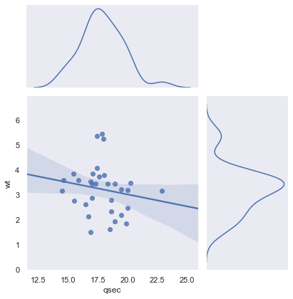

```python
g1=sns.JointGrid(x='qsec', y='wt', data=data,
                   space=0.1, height=6, ratio=2)
g1 = g1.plot(sns.regplot, sns.kdeplot)
```

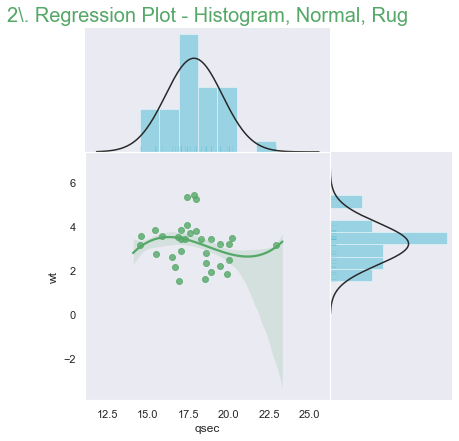

```python
g2 = sns.JointGrid(x='qsec', y='wt', data=data, space=0, ratio=2)
g2 = g2.plot_joint(sns.regplot, color="g", order=3, ci=68 )
g2 = g2.plot_marginals(sns.distplot, kde=False, rug=True, fit=norm, color="#1EAFCD23")
g2.ax_marg_x.set_title('2\. Regression Plot - Histogram, Normal, Rug', size=20, color='g')
```

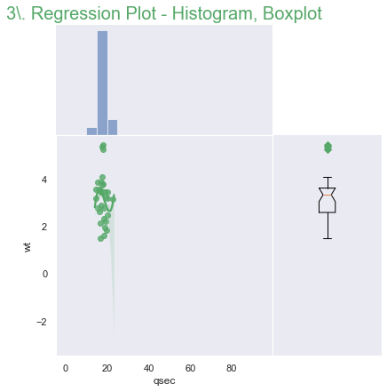

```python
g3 = sns.JointGrid(x='qsec', y='wt', data=data,
                   space=0, ratio=2)
g3 = g3.plot_joint(sns.regplot, color="g", order=3, ci=68)
g3.ax_marg_x.hist(data.qsec, color="b", alpha=.6,
                  bins=np.arange(0, 100, 5))
g3.ax_marg_y.boxplot(data.wt, 1, 'gD')
g3.ax_marg_x.set_title('3\. Regression Plot - Histogram, Boxplot',
                        size=20, color='g');
```

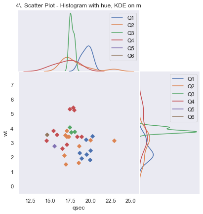

```python
#在JointGrid上实现hue：

g4 = sns.JointGrid(x='qsec', y='wt', data=data,space=0, ratio=2)
i=1
for quarter, sales in data.groupby('carb'):
    sns.kdeplot(sales.qsec, ax=g4.ax_marg_x, label='Q'+str(i));
    sns.kdeplot(sales.wt, ax=g4.ax_marg_y, vertical=True,
             label='Q'+str(i));
    g4.ax_joint.plot(sales.qsec,sales.wt,"D", ms=5)
    i +=1
    g4.ax_marg_x.set_title('4\. Scatter Plot - Histogram with hue, KDE on m')
```

## pairplot和PairGrid()

pairplot()和PairGrid()允许在一个语句中将数据集中的所有数值变量成对绘制为两个。 这是了解整个数据集中变量之间存在的高级关系和联合的快速方法。 这加快了机器学习项目的特征设计过程。pairplot()对于双变量绘图只有两个选项：散点图和回归。PairGrid()没有任何这样的限制。

```python
import matplotlib.pyplot as plt
import seaborn as sns
sns.set(rc={"axes.linewidth": 1, "xtick.major.width": 1,
            "ytick.major.width": 1,
            "xtick.major.size": 5, "ytick.major.size": 5},
             style="ticks", context="paper",
             font_scale=1.25)
```

### pariplot

有三种方法可以指定要使用pairplot()绘制的网格类型。 让我们绘制所有三种格式并查看其中的区别：

在提供的数据集中绘制所有数字变量：

```
sns.pairplot(snacks_sales_items, hue='Promotion', kind='reg')
plt.show();
```

从提供的数据集中绘制所选变量：

```
sns.pairplot(snacks_sales, vars=['Coffee', 'Pies'], hue='Promotion',
             kind='reg')
plt.show();
```

在行和列网格中绘制从提供的数据集中选择的变量，类似于我们先前使用的方面变量：

```
g = sns.pairplot(snacks_sales, x_vars=['Coffee', 'Pies', 'Cakes'],
                 y_vars=['Cookies', 'Smoothies'],
                 hue='Promotion', kind='scatter')
g.fig.subplots_adjust(wspace=.02, hspace=.02);
plt.show();
```

```python
#新建data1
data.head(5)
data1=data[['disp','hp','wt','qsec','cyl']]
```

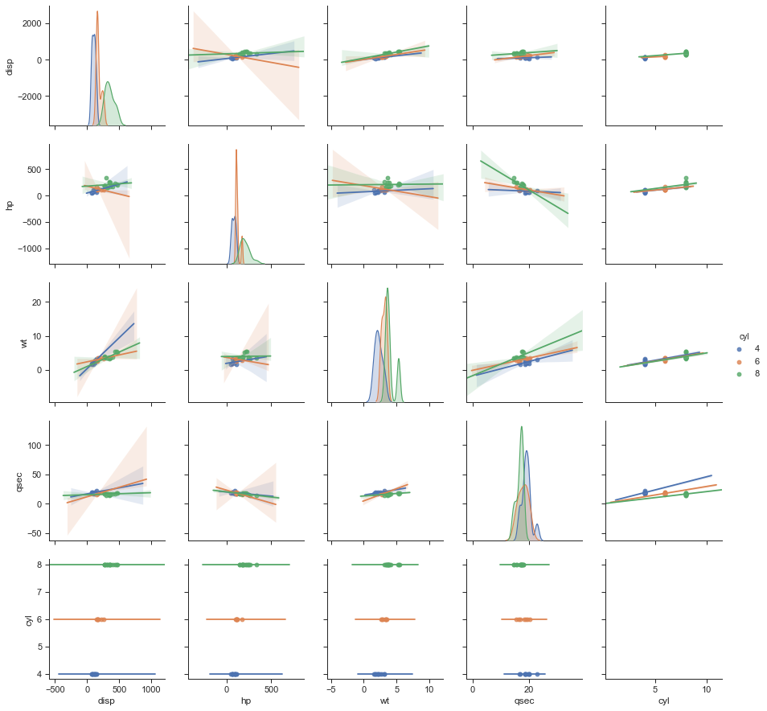

```python
sns.pairplot(data1, hue='cyl', kind='reg')
plt.show()
```

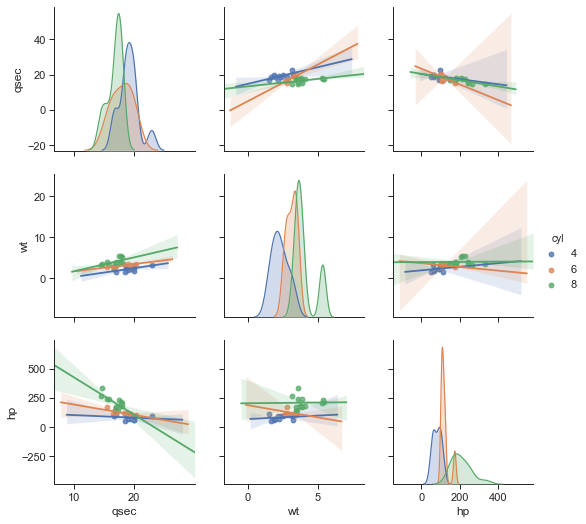

```python
sns.pairplot(data1,vars=['qsec','wt','hp'], hue='cyl', kind='reg')
plt.show()
```

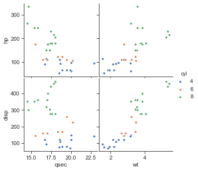

```python
g = sns.pairplot(data1, x_vars=['qsec','wt'],
                 y_vars=['hp', 'disp'],
                 hue='cyl', kind='scatter')
g.fig.subplots_adjust(wspace=.02, hspace=.02);
plt.show()
```

### PairGrid

PairGrid()与pairplot()的工作原理非常相似，但提供了更大的灵活性，可以将任何类型的图分别用于对角线，非对角线甚至更低和更高的对角线图。 但是，PairGrid()不支持pairplot()的行和列矩阵网格，因为它沿对角线使用单变量图，而行和列网格仅具有双变量绘图。

除了完整的数据集和选定的变量列表之外，它还有三种方法可以在网格中指定图的特定类型：

对网格中的所有图形单元/轴域使用相同类型的图：

```
g = sns.PairGrid(snacks_sales_items, hue='Promotion', hue_kws=
                {"marker": ["^", "D"]},
                 palette={'Yes': 'blue', 'No': '#00a99f05'})
g.map(plt.scatter, edgecolor='k', s=50)
g.add_legend()
g.fig.subplots_adjust(wspace=.02, hspace=.02);
```

将一种类型的单变量图用于对角线，将另一种双变量类型用于非对角线图：

```
g = sns.PairGrid(snacks_sales_items, vars=['Coffee', 'Pies',
                 'Smoothies'], hue='Promotion', palette={'Yes':
                 'Orange', 'No': 'g'})
g.map_diag(plt.hist, histtype="step", linewidth=2)
g.map_offdiag(sns.kdeplot, n_levels=25, cmap="coolwarm")
g.add_legend()
g.fig.subplots_adjust(wspace=.02, hspace=.02);
```

对于对角线使用一种单变量，对于右上角对角线使用一种双变量类型，对于左下角对角线图使用另一种双变量类型：

```
g = sns.PairGrid(snacks_sales_items, vars=['Cakes', 'Pies',
                 'Cookies'], hue='Promotion',
                 palette={'Yes': 'darkblue', 'No': 'r'})
g.map_diag(sns.stripplot, jitter=True)
g.map_upper(sns.regplot, order=2, ci=90)
g.map_lower(sns.residplot, order=2, lowess=True)
g.add_legend();
```

g.add_legend()将图例添加到图形的中。 由于某些原因，seaborn不会像所有其他类型的绘图一样自动添加！

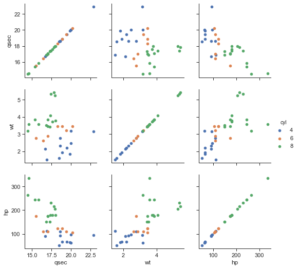

```python
g=sns.PairGrid(data1,hue='cyl',vars=['qsec','wt','hp'])
g.map(plt.scatter)
g.add_legend()
```

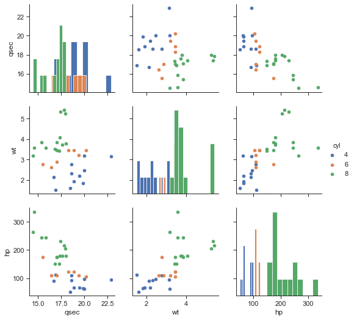

```python
g=sns.PairGrid(data1,hue='cyl',vars=['qsec','wt','hp'])
g.map_diag(plt.hist)
g.map_offdiag(plt.scatter)
g.add_legend()
```

[output not shown]

[output cut: 495 more lines]

[output not shown]

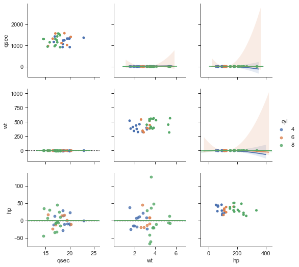

```python
g=sns.PairGrid(data1,hue='cyl',vars=['qsec','wt','hp'])
g.map_diag(sns.stripplot, jitter=True)
g.map_upper(sns.regplot, order=2, ci=90)
g.map_lower(sns.residplot, order=2, lowess=True)
g.add_legend()
```

## FacetGrid

FacetGrid()用于执行，语义变量hue，style和size以及方面变量row和col进行多维分析。 当我们了解关系图和类别图时，我们已经间接使用了这些功能。

FacetGrid()是先把语义变量和方面变量结合数据创造好网格，然后再确定绘图，并且选择主要变量。

第一步：`sns.FacetGrid`传入数据并且利用语义和方面变量构造号网格。`g = sns.FacetGrid(snacks_sales, col="Promotion", row="weekend", height=3)`

第二步：`g.map()`确定绘图好变量并且设置参数,g = g.map(plt.hist, "Cookies", bins=10, color='m')

```python
import matplotlib.pyplot as plt
import seaborn as sns

## The following parameters are set in rc configuration file, so they  will be applicable for the entire session
## font_scale factor is the multiplier of default font size(instead of absolute size, it is relative size)
sns.set(rc={"axes.linewidth": 1, "xtick.major.width": 1,
            "ytick.major.width": 1,
            "xtick.major.size": 5, "ytick.major.size": 5},
             style="ticks", context="paper",
             font_scale=1.25)
```

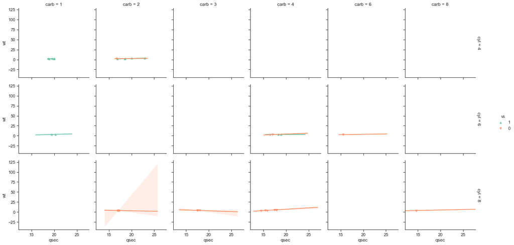

```python
g = sns.FacetGrid(data, col="carb", row="cyl",
                  hue="vs",hue_order=[1,0],
                  height=3, margin_titles=True, palette="Set2",
                  hue_kws=dict(marker=["^", "v"]))
g = g.map(sns.regplot, "qsec","wt")
g.add_legend()
```

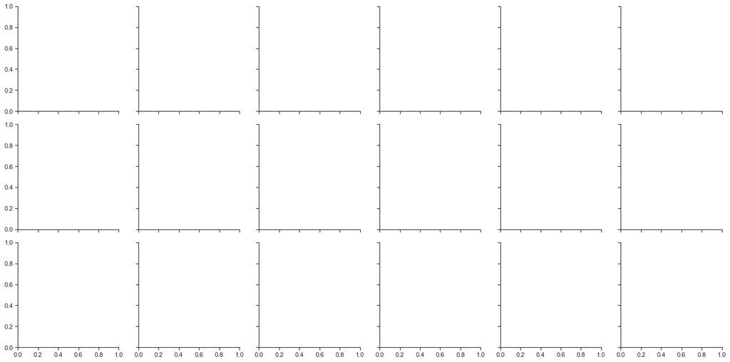

```python
g = sns.FacetGrid(data, col="carb", row="cyl",
                  hue="vs",hue_order=[1,0],
                  height=3, margin_titles=True, palette="Set2",
                  hue_kws=dict(marker=["^", "v"]))
```

# 矩阵图

尽管pairplot()和PariGrid()可以绘制每个变量包含两个变量的网格中的多个变量之间的关系，但矩阵图可以通过使用与变量相关的聚合度量（例如相关性，协方差）以矩阵格式启用此格式，或者可以正常使用两个相关变量的财务，销售或运营等数据。

Seaborn 提供了两个矩阵图，heatmap()和clustermap()。

Heatmap()提供数字的彩色表示，以了解数字的增加，减少，偏离或收敛的趋势，这可能不容易直接用数字捕捉，特别是当数字太小或太大时。

Clustermap()使用分层聚类方法，并绘制和生成的树状图。

## 热图

热图通过使用色表表示颜色中的数字，因此我们的眼睛可以捕捉到和数据中各种变量的相对强度。

```
annot=True指定在图上显示实际数字。
fmt='.0f'指定和数字应以整数格式显示，没有任何十进制值。

robust=True：当未指定vmin和vmax范围时，色表范围是通过降低异常值的权重得出的。
center=sales.loc[3, 'Cookies']将此颜色表的中心颜色设置为该值，并将颜色条调整为要绘制的数据范围。 如果选择的值在数据范围的任意一个极端上，则仅将原始色表的一半用于新色条。

robust=True：当未指定vmin和vmax范围时，色表范围是通过降低异常值的权重得出的。
vmin=200是的下限，vmax=600是上限。 数据中低于下限的所有数字，都以颜色条的下端着色，高于上限的数字都以颜色条的上端着色。

grid_kws = {"height_ratios": (.9, .05), "hspace": .4}是网格的参数字典。 和两个轴域的高度之比为0.9:0.05，因此和色条轴域的高度与绘图高度相比非常短。 两个轴域之间的水平间距为 0.4。
cbar_ax=cbar_ax指定颜色条轴域。cbar_kws={"orientation": "horizontal"})绘制水平颜色条。
```

```
[Text(0.5, 1.0, 'Colorbar range(200, 600)'), Text(721.8235294117648, 0.5, '')]
```

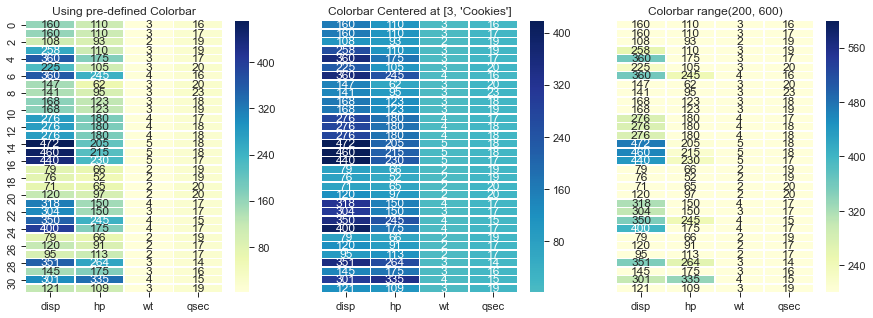

```python
fig, (ax1, ax2, ax3) = plt.subplots(1,3, figsize=(15,5))
sns.heatmap(data1.iloc[:,:4], annot=True, fmt='.0f', linewidths=.5,
            cmap="YlGnBu", ax=ax1)
ax1.set_title('Using pre-defined Colorbar')
sns.heatmap(data1.iloc[:,:4], annot=True, fmt='.0f',linewidths=.5, robust=True,
            cmap="YlGnBu", center=data1.iloc[3, 3],
            yticklabels=False, ax=ax2)
ax2.set_title("Colorbar Centered at [3, 'Cookies']")
sns.heatmap(data1.iloc[:,:4], annot=True, fmt='.0f',linewidths=.5, robust=True,
            vmin=200, vmax=600,
            cmap="YlGnBu", yticklabels=False, ax=ax3)
ax3.set(title='Colorbar range(200, 600)', ylabel='')
```

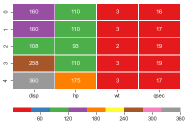

```python
grid_kws = {"height_ratios": (.9, .05), "hspace": .4}
f, (plot_ax, cbar_ax) = plt.subplots(2, gridspec_kw=grid_kws)
ax = sns.heatmap(data1.iloc[:5,:4], ax=plot_ax, cmap="Set1", annot=True,
                 fmt='.0f',linewidths=.5,
                 cbar_ax=cbar_ax, cbar_kws={"orientation":
                 "horizontal"});
```

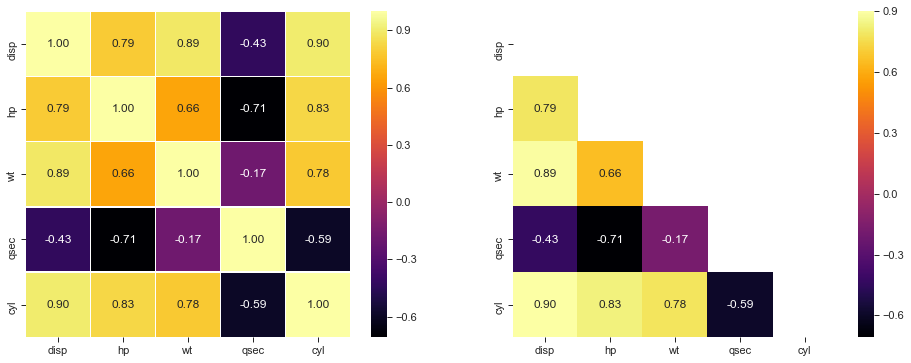

```python
corr=data1.corr()
fig, (ax1, ax2) = plt.subplots(1,2, figsize=(16,6))
sns.heatmap(corr, annot=True, fmt='.2f',linewidths=.5,
            cmap="inferno", ax=ax1)
mask = np.zeros_like(corr)
mask[np.triu_indices_from(mask)] = True
sns.heatmap(corr, mask=mask, vmax=.9, annot=True, fmt='.2f',
            cmap="inferno", ax=ax2)
```

[output not shown]

## 群集图

顾名思义，clustermap()使用分层聚类方法对数据集中的各种变量进行聚类，并绘制和生成的树状图。

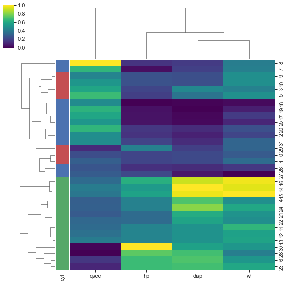

```python
row_colors = data1["cyl"].map(dict(zip(data1["cyl"].unique(), "rbg")))
g = sns.clustermap(data1.drop('cyl',axis=1),
                   standard_scale=1, robust=True,
                   row_colors=row_colors, cmap='viridis')
```

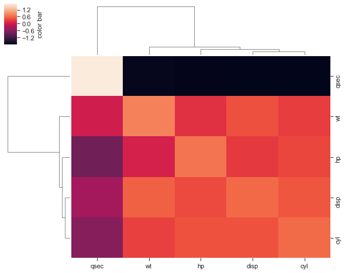

```python
corr=data1.corr()
g = sns.clustermap(corr, figsize=(10,8),  z_score=1, cbar_kws={"label":
                                                        "color bar"})
```